# Machine Learning Project

Kondalarao Palaka

December 25, 2015

This is a project report submitted to the Practical Machine Learning class offered by Johns Hopkins University on Coursera.

The project involves classifying how well a person is performing a given exercise based on accelerometer readings from various parts of the participantbs body. Such accelerometer readings are provided by popular products such as FitBit and FuelBand.

The data for the project is generously provided by the Human Activity Recognition project at Gropware Technologies ( http://groupware.les.inf.puc-rio.br/har ).

## 1. Data Collection and Feature Identification

Data is downloaded in the form of .csv files from the above website.

There are two data sets made available: - A training set with 19622 observations of 160 variables (outcome var is b classeb ). - A test set with 20 observations of 160 variables.

A large number of variables adds to computational effort without contributing to the signal in the data. To prune the number of variables, itbs noted that:

- variables like timestamp (i.e.B at what time an activity was performed) shouldnbt have any bearing on the quality of the exercise
- test set has NAs /blanks for a large number of variables; predictions wonbt be using these variables.

```r
trd_full <- read.csv("pml-training.csv")
tsd_full <- read.csv("pml-testing.csv")
tsd_full[tsd_full==""] <- NA  #replace blanks with NA
tsd_full <- tsd_full[,colSums(is.na(tsd_full))==0]  #remove vars where test data has NAs
tsd_full <- tsd_full[,-c(1,3,4,5,6,60)] #additionally, remove timestamps etc
# 54 vars
cleancols <- names(tsd_full)
# prune the training set to include the same clean variables as test set (and, of course, the outcome var)
trd_clean <- trd_full[,c("classe",cleancols)]

# convert user_name (factor) to integer (numeric) so that varImp() doesn't explode the number of variables
tsd_full$user_name <- as.integer(tsd_full$user_name)
trd_clean$user_name <- as.integer(trd_clean$user_name)
```

## 2. Machine Learning Algorithm/Model

Given all the superior qualities of random forest classication model, I have decided to apply it to my activity classification project.

Some of the highlights of random forest model:

- One of the most used/accurate algorithms
- Can be slow (hence use parallelization)
- may overfit (make sure to cross validate and also to keep an untouched test set for accurate OOS error estimates)

## 3. Model Training

- Data Slicing To be able to estimate an unbiased out of sample error for the model, I have set aside 20% of the training set. I trained the model on the remaining 80% with cross validation (0.75/0.25). In other words, I use 20% of data for validation, another 20% for testing (25% of 80% is 20% of total) and the remaining 60% for training. This is per the standard recommendations.
- No preprocessing (e.g.B center, scale) is done to protect the integer nature of several variable
- variable importance Used varImp() and plotted the relative importance of the various features.
- Parallelization I used the doMC library to make use of the 4 cores on my computer.

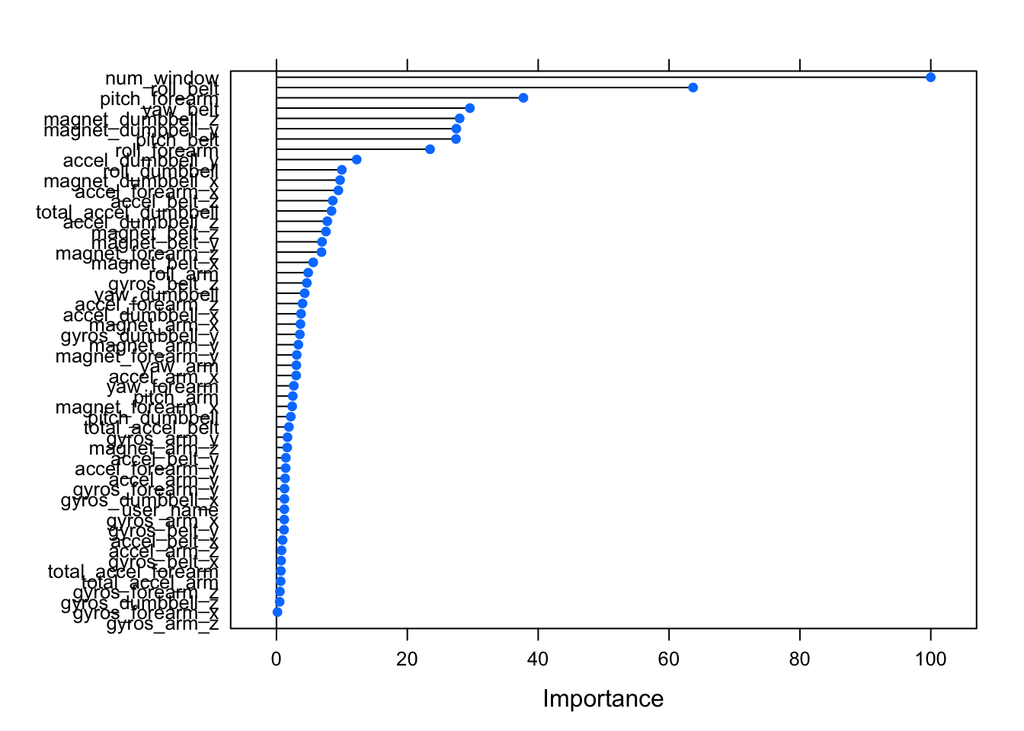

```r
library(caret)

intrain1 <- createDataPartition(y=trd_clean$classe, p=0.80, list=FALSE)
trd_train_1 <- trd_clean[intrain1,]
trd_test_1 <- trd_clean[-intrain1,]

library(doMC)
registerDoMC(cores=4)

rf2 <- train(classe~.,
             data=trd_train_1,
             method="rf",
             ntree=500,
             trControl = trainControl(method="cv", p=0.75, allowParallel = TRUE)
)

vi2 <- varImp(rf2, scale=TRUE)
plot(vi2,top=54)
```

## 4. Out of Sample/Bag Error Estimation

For the purposes of OOS error estimation, I use the 20% of the training data set thatbs been set aside untouched.

```r
p_trd_test_1 <- predict(rf2,trd_test_1)
# out of sample error estimation
confusionMatrix(p_trd_test_1,trd_test_1$classe)
```

```
## Confusion Matrix and Statistics
##
##           Reference
## Prediction    A    B    C    D    E
##          A 1116    3    0    0    0
##          B    0  755    1    0    0
##          C    0    1  683    1    0
##          D    0    0    0  641    0
##          E    0    0    0    1  721
##
## Overall Statistics
##
##                Accuracy : 0.9982
##                  95% CI : (0.9963, 0.9993)
##     No Information Rate : 0.2845
##     P-Value [Acc > NIR] : < 2.2e-16
##
##                   Kappa : 0.9977
##  Mcnemar's Test P-Value : NA
##
## Statistics by Class:
##
##                      Class: A Class: B Class: C Class: D Class: E
## Sensitivity            1.0000   0.9947   0.9985   0.9969   1.0000
## Specificity            0.9989   0.9997   0.9994   1.0000   0.9997
## Pos Pred Value         0.9973   0.9987   0.9971   1.0000   0.9986
## Neg Pred Value         1.0000   0.9987   0.9997   0.9994   1.0000
## Prevalence             0.2845   0.1935   0.1744   0.1639   0.1838
## Detection Rate         0.2845   0.1925   0.1741   0.1634   0.1838
## Detection Prevalence   0.2852   0.1927   0.1746   0.1634   0.1840
## Balanced Accuracy      0.9995   0.9972   0.9990   0.9984   0.9998
```

As shown above, the out of sample/bag accuracy is **99.82%** with just 7 test cases (out of about 4,000) being misclassified.

## 5. Predictions for Test Set

Used the model to predict classe variable for the test data (20 observations). Based on the feedback, the predictions are 100% accurate.

```r
predict(rf2, tsd_full)
```

```
##  [1] B A B A A E D B A A B C B A E E A B B B
## Levels: A B C D E
```